# Host Population Characteristics

Elizabeth Anderson

7/22/2020

## Loading and Summarizing Metadata Info

To start off, we need to access the metadata that we have. It’s currently in the form of an rds file (created by the R script ‘preparing_2020_T2D_metadata.R’).

```r
metadata_df <- readRDS('final_metadata.rds')
# Add summary statistics for the data (across cohorts and separately)
skim(metadata_df)
```

Data summary

| Name | metadata_df |
| --- | --- |
| Number of rows | 664 |
| Number of columns | 15 |
| _______________________ |  |
| Column type frequency: |  |
| character | 12 |
| numeric | 3 |
| ________________________ |  |
| Group variables | None |

**Variable type: character**

| skim_variable | n_missing | complete_rate | min | max | empty | n_unique | whitespace |
| --- | --- | --- | --- | --- | --- | --- | --- |
| dataset | 0 | 1.00 | 3 | 8 | 0 | 3 | 0 |
| PatientID | 43 | 0.94 | 7 | 19 | 0 | 621 | 0 |
| sampleID | 26 | 0.96 | 2 | 9 | 0 | 533 | 0 |
| disease | 69 | 0.90 | 1 | 1 | 0 | 2 | 0 |
| age | 69 | 0.90 | 2 | 18 | 0 | 301 | 0 |
| Gender | 45 | 0.93 | 4 | 6 | 0 | 2 | 0 |
| country | 50 | 0.92 | 3 | 3 | 0 | 12 | 0 |
| Ethnicity | 51 | 0.92 | 1 | 7 | 0 | 16 | 0 |
| BMI | 69 | 0.90 | 2 | 18 | 0 | 423 | 0 |
| HDL | 58 | 0.91 | 1 | 19 | 0 | 289 | 0 |
| LDL | 56 | 0.92 | 1 | 19 | 0 | 408 | 0 |
| TGL | 53 | 0.92 | 1 | 19 | 0 | 372 | 0 |

**Variable type: numeric**

| skim_variable | n_missing | complete_rate | mean | sd | p0 | p25 | p50 | p75 | p100 | hist |
| --- | --- | --- | --- | --- | --- | --- | --- | --- | --- | --- |
| CHOL | 85 | 0.87 | 9.49 | 3.02 | 2.21 | 6.87 | 10.02 | 11.62 | 19.55 | ▃▃▇▂▁ |
| CR | 418 | 0.37 | 41.49 | 36.15 | 0.55 | 0.94 | 58.00 | 69.00 | 182.00 | ▇▇▂▁▁ |
| HSCRP | 455 | 0.31 | 3.89 | 8.32 | 0.00 | 0.93 | 1.64 | 3.53 | 99.22 | ▇▁▁▁▁ |

```r
skim(metadata_df, age)
```

Data summary

| Name | metadata_df |
| --- | --- |
| Number of rows | 664 |
| Number of columns | 15 |
| _______________________ |  |
| Column type frequency: |  |
| character | 1 |
| ________________________ |  |
| Group variables | None |

**Variable type: character**

| skim_variable | n_missing | complete_rate | min | max | empty | n_unique | whitespace |
| --- | --- | --- | --- | --- | --- | --- | --- |
| age | 69 | 0.9 | 2 | 18 | 0 | 301 | 0 |

## Visualizing the Metadata

### Age

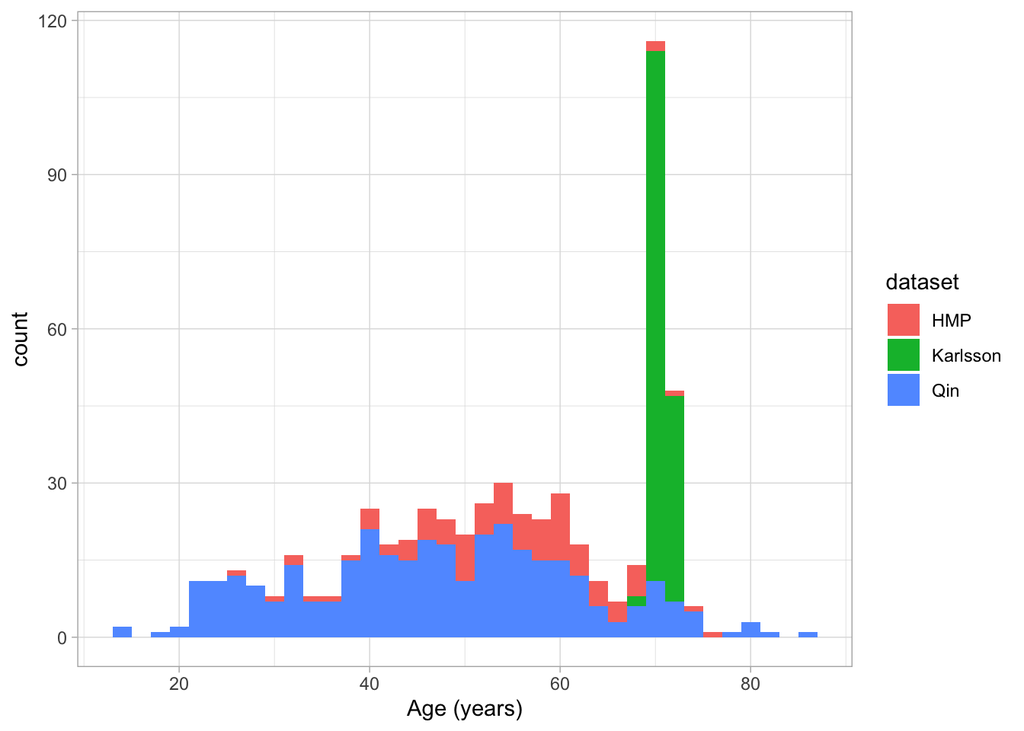

```r
tibbleData = as_tibble(metadata_df)
tibbleData <- tibbleData %>% filter(age != "NA")
tibbleData$age <- as.numeric(tibbleData$age)

ggplot(tibbleData, aes(x=age, fill = dataset)) +
  geom_histogram(binwidth = 2) +
  theme_light() +
  scale_x_continuous(name ="Age (years)",
                    breaks = scales::pretty_breaks(n = 5))
```

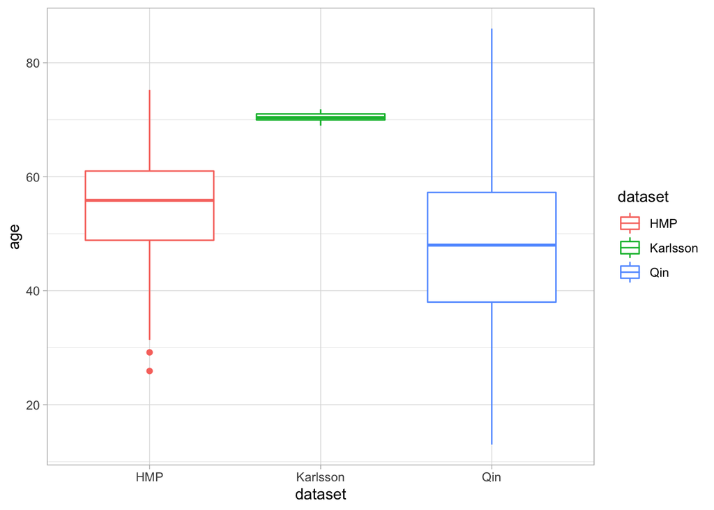

```r
ggsave("Metadata_Figures/age_histogram.png")
tibbleData = as_tibble(metadata_df)
tibbleData <- tibbleData %>% filter(age != "NA")
tibbleData$age <- as.numeric(tibbleData$age)

ggplot(tibbleData, aes(y=age, x= dataset)) +
  geom_boxplot(aes(color = dataset)) +
  theme_light()
```

```r
ggsave("Metadata_Figures/age_boxplot.png")
```

### Gender

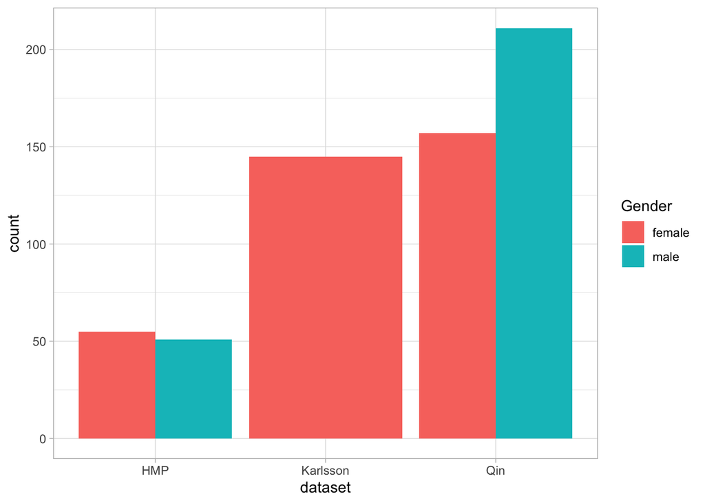

```r
tibbleData = as_tibble(metadata_df)
tibbleData <- tibbleData %>% filter(Gender != "NA")

ggplot(tibbleData, aes(x=dataset, fill = Gender)) +
  geom_bar(position=position_dodge()) +
  theme_light()
```

```r
ggsave("Metadata_Figures/Gender_barplot.png")
```

### Disease Condition

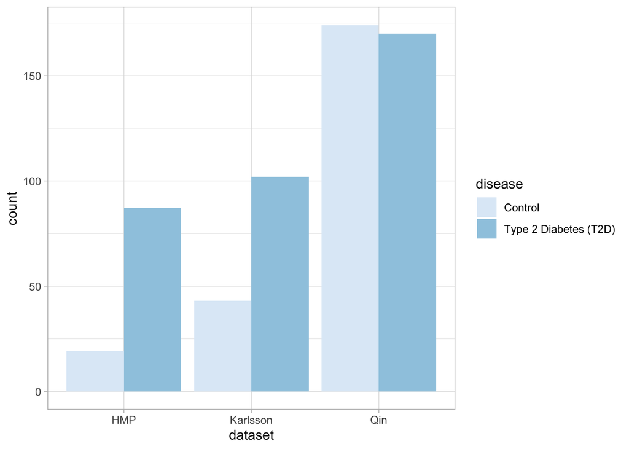

```r
tibbleData = as_tibble(metadata_df)
tibbleData <- tibbleData %>% filter(disease != "NA")

ggplot(tibbleData, aes(x=dataset, fill = disease)) +
  geom_bar(position=position_dodge()) +
  scale_fill_brewer(palette = "Blues",
                     labels = c("Control", "Type 2 Diabetes (T2D)")) +
  theme_light()
```

```r
ggsave("Metadata_Figures/disease_barplot.png")
```

### Body-Mass Index (BMI)

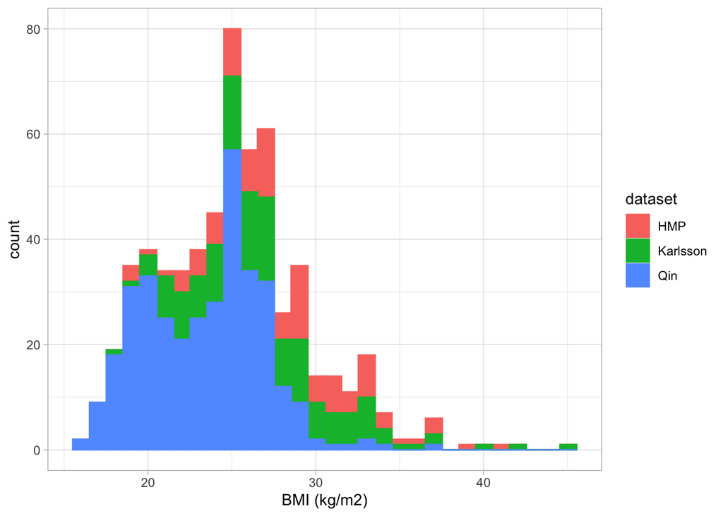

```r
tibbleData = as_tibble(metadata_df)
tibbleData <- tibbleData %>% filter(BMI != "NA")
tibbleData$BMI <- as.numeric(tibbleData$BMI)

ggplot(tibbleData, aes(x=BMI, fill=dataset, color=dataset)) +
  geom_histogram() +
  theme_light() +
  xlab('BMI (kg/m2)')
```

```r
ggsave("Metadata_Figures/BMI_histogram.png")
```

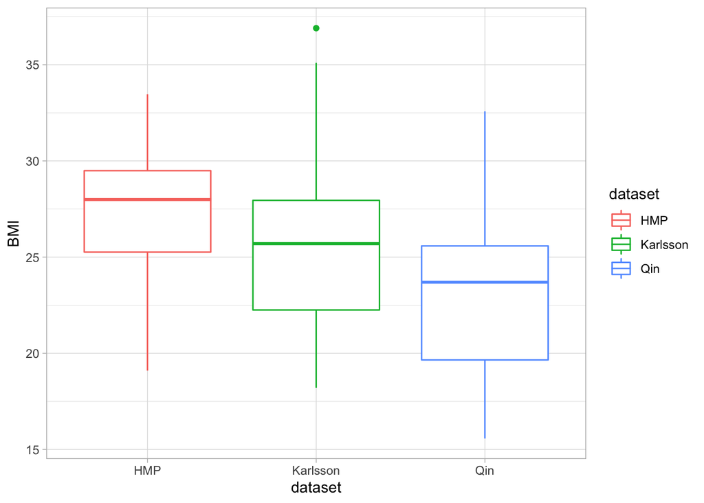

```r
tibbleData = as_tibble(metadata_df)
tibbleData <- tibbleData %>% filter(age != "NA")
tibbleData$BMI <- as.numeric(tibbleData$BMI)
tibbleData <- tibbleData %>%
  filter(disease == 0)

ggplot(tibbleData, aes(y=BMI, x= dataset)) +
  geom_boxplot(aes(color = dataset)) +
  theme_light()
```

```r
ggsave("Metadata_Figures/BMI_Filtered_boxplot.png")
```

### Cholesterol

Units: (mmol/L)

“Cholesterol is a waxy, fat-like substance that’s found in all the cells in your body. Your body needs some cholesterol to make hormones, vitamin D, and substances that help you digest foods. Your body makes all the cholesterol it needs.” (taken from https://medlineplus.gov/cholesterol.html)

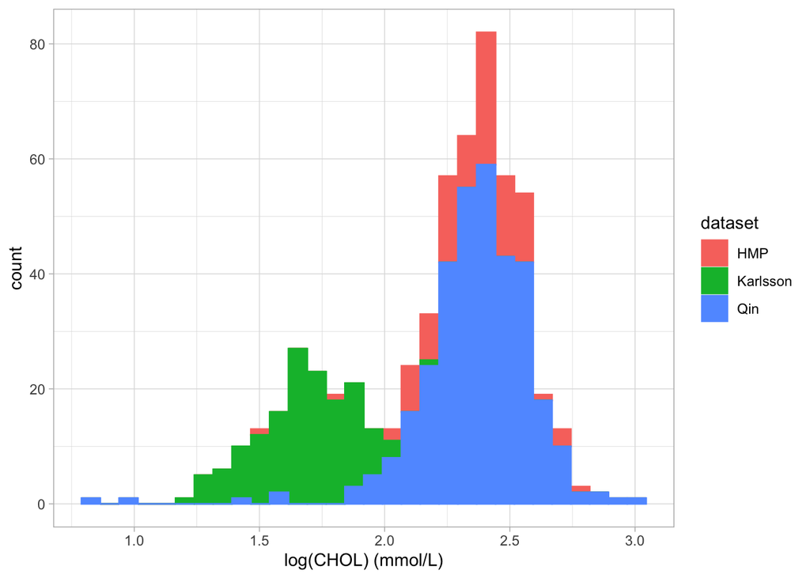

```r
metadata_df <- readRDS('final_metadata.rds')
tibbleData = as_tibble(metadata_df)
tibbleData <- tibbleData %>% filter(CHOL != "NA")
tibbleData$CHOL <- as.numeric(tibbleData$CHOL)
tibbleData$CHOL <- log(tibbleData$CHOL)

ggplot(tibbleData, aes(x=CHOL, color = dataset, fill = dataset)) +
  geom_histogram() +
  theme_light() +
  xlab('log(CHOL) (mmol/L)')
```

```r
ggsave("Metadata_Figures/CHOL_histogram.png")
```

### HDL

Units: mmol/L (non-US measurements)

“HDL cholesterol is often called”good" cholesterol. The test for HDL cholesterol measures the amount of HDL-C in blood. High levels of cholesterol have been shown to be associated with the development of hardening of the arteries (atherosclerosis) and heart disease" (taken from https://labtestsonline.org/tests/hdl-cholesterol)

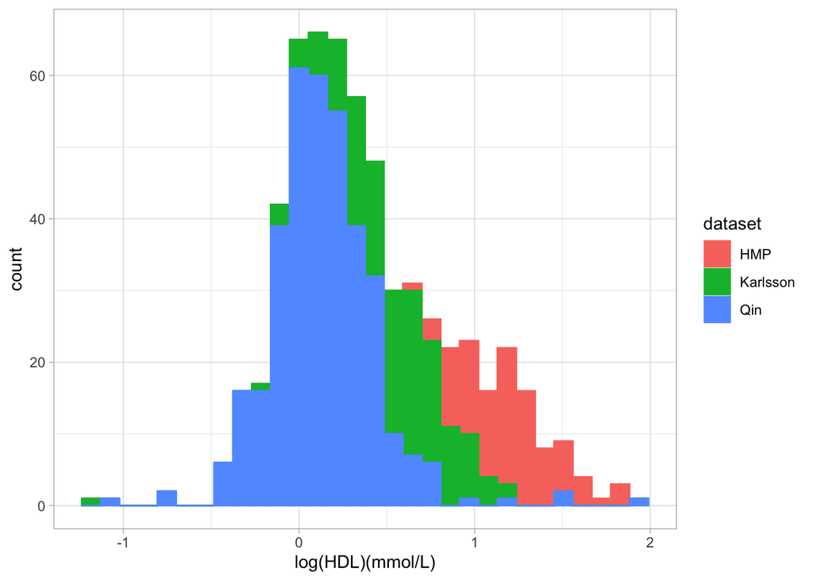

```r
metadata_df <- readRDS('final_metadata.rds')
tibbleData = as_tibble(metadata_df)
tibbleData <- tibbleData %>% filter(HDL != "NA")
tibbleData$HDL <- as.numeric(tibbleData$HDL)
tibbleData$HDL <- log(tibbleData$HDL)

ggplot(tibbleData, aes(x=HDL, color = dataset, fill = dataset)) +
  geom_histogram() +
  theme_light() +
  xlab('log(HDL)(mmol/L)')
```

```r
ggsave("Metadata_Figures/HDL_histogram.png")
```

### LDL

Units: mmol/L (non-US measurements)

“LDL stands for low-density lipoproteins. It is sometimes called the”bad" cholesterol because a high LDL level leads to a buildup of cholesterol in your arteries. HDL stands for high-density lipoproteins." (taken from https://medlineplus.gov/ldlthebadcholesterol.html)

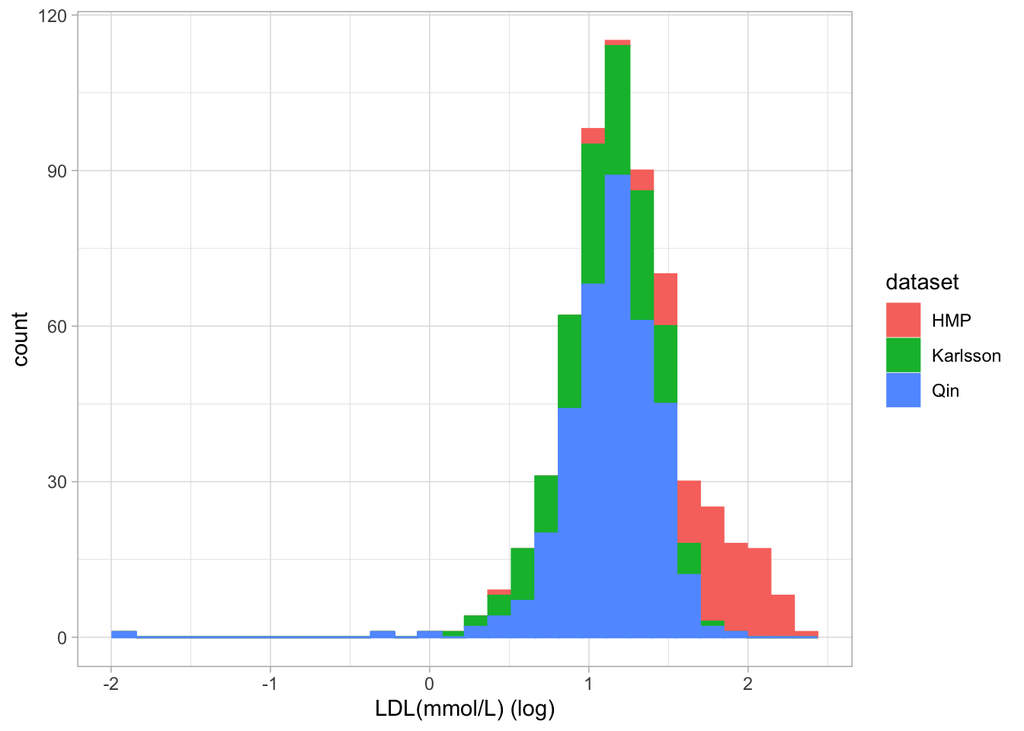

```r
metadata_df <- readRDS('final_metadata.rds')
tibbleData = as_tibble(metadata_df)
tibbleData <- tibbleData %>% filter(LDL != "NA")
tibbleData$LDL <- as.numeric(tibbleData$LDL)
tibbleData$LDL <- log(tibbleData$LDL)

ggplot(tibbleData, aes(x = LDL, color=dataset,fill = dataset)) +
  geom_histogram() +
  theme_light() +
  xlab('LDL(mmol/L) (log)')
```

```r
ggsave("Metadata_Figures/LDL_histogram.png")
```

### HSCRP

Units: mg/L (non-US measurements)

“The hsCRP test is a highly sensitive quantification of CRP, an acute-phase protein released into the blood by the liver during inflammation, which has been associated with the presence of heart disease… Elevated hsCRP is associated with the risk of future adverse cardiovascular events (heart attack, stroke and death) in apparently healthy individuals1,3 and in individuals with stable coronary artery disease.” (taken from https://www.clevelandheartlab.com/wp-content/uploads/2013/09/hsCRP-Practitioner-One-Pager-CHL-D009b.pdf)

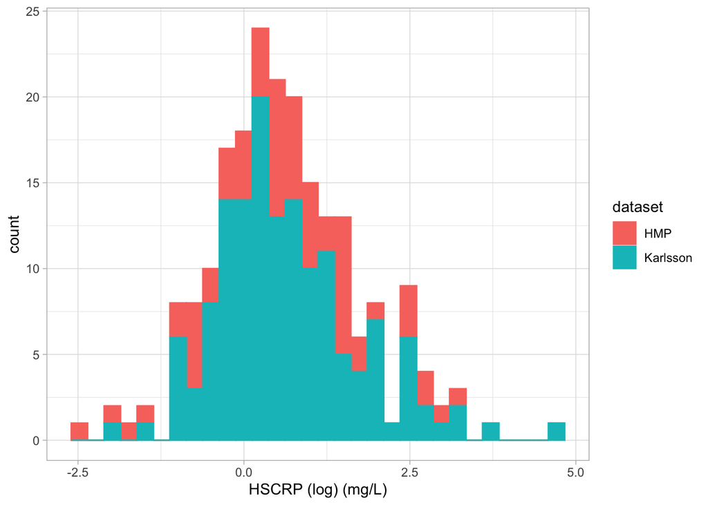

```r
metadata_df <- readRDS('final_metadata.rds')
tibbleData = as_tibble(metadata_df)
tibbleData <- tibbleData %>% filter(HSCRP != "NA")
tibbleData$HSCRP <- as.numeric(tibbleData$HSCRP)
tibbleData$HSCRP <- log(tibbleData$HSCRP)

ggplot(tibbleData, aes(color=dataset, fill = dataset, x=HSCRP)) +
  geom_histogram() +
  theme_light() +
  xlab('HSCRP (log) (mg/L)')
```

```r
ggsave("Metadata_Figures/HSCRP_histogram.png")
```

### Triglycerides

Units: mmol/L (non-US measurements)

"Triglycerides are a type of fat (lipid) found in your blood.

When you eat, your body converts any calories it doesn’t need to use right away into triglycerides. The triglycerides are stored in your fat cells. Later, hormones release triglycerides for energy between meals.

If you regularly eat more calories than you burn, particularly from high-carbohydrate foods, you may have high triglycerides (hypertriglyceridemia)." (taken from https://www.mayoclinic.org/diseases-conditions/high-blood-cholesterol/in-depth/triglycerides/art-20048186)

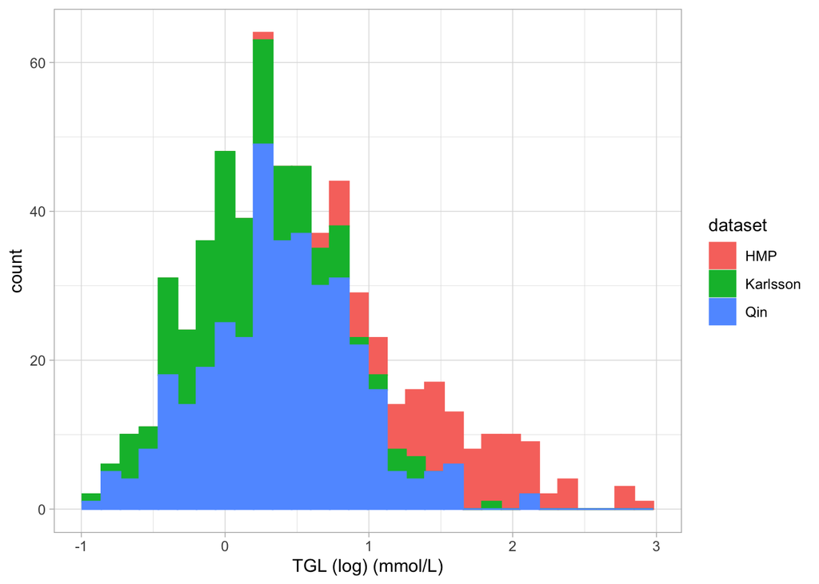

```r
metadata_df <- readRDS('final_metadata.rds')
tibbleData = as_tibble(metadata_df)
tibbleData <- tibbleData %>% filter(TGL != "NA")
tibbleData$TGL <- as.numeric(tibbleData$TGL)
tibbleData$TGL <- log(tibbleData$TGL)

ggplot(tibbleData, aes(x=TGL, color = dataset, fill = dataset)) +
  geom_histogram() +
  theme_light() +
  xlab('TGL (log) (mmol/L)')
```

```r
ggsave("Metadata_Figures/TGL_histogram.png")
```